# Computer Assignment 1

## Parmis Vaghef Davari 810100260

## Genetics Algorithm: Knapsack Problem

### Problem Description:

Assuming we have a backpack, we have to fill this backpack with a number of items each with certain weights and values. The goal in thus problem is to use certain amount of items that don't exceed the **weight limit** of the problem. Also, the items and their amounts should be chosen in a way that do exceed the **value limit** of the problem. Also, there is another constraint in the problem, we can only choose items of variety in a certain numeric range. We want to solve this problem with these constraints:

1. Weight Limit = 10
2. Minimum Value = 12
3. Items in variety chosen in range (2,4)

### Goal:Maximize the total value of selected snacks while adhering to the specified constraints.

First, we load the data and check some of its' features

```python
import pandas as pd
data_frame = pd.read_csv("snacks.csv")
```

```python
data_frame.head(20)
```

|  | Snack | Available Weight | Value |
| --- | --- | --- | --- |
| 0 | MazMaz | 10 | 10 |
| 1 | Doogh-e-Abali | 15 | 10 |
| 2 | Nani | 5 | 5 |
| 3 | Jooj | 7 | 15 |
| 4 | Hot-Dog | 20 | 15 |
| 5 | Chips | 8 | 6 |
| 6 | Nooshaba | 12 | 8 |
| 7 | Shokolat | 6 | 7 |
| 8 | Chocoroll | 9 | 12 |
| 9 | Cookies | 11 | 11 |
| 10 | Abnabat | 4 | 4 |
| 11 | Adams-Khersi | 14 | 9 |
| 12 | Popcorn | 16 | 13 |
| 13 | Pastil | 3 | 7 |
| 14 | Tordilla | 10 | 9 |
| 15 | Masghati | 5 | 6 |
| 16 | Ghottab | 7 | 10 |
| 17 | Saghe-Talaei | 9 | 11 |
| 18 | Choob-Shoor | 13 | 12 |

```python
data_frame.describe()
```

|  | Available Weight | Value |
| --- | --- | --- |
| count | 19.000000 | 19.000000 |
| mean | 9.684211 | 9.473684 |
| std | 4.497563 | 3.168744 |
| min | 3.000000 | 4.000000 |
| 25% | 6.500000 | 7.000000 |
| 50% | 9.000000 | 10.000000 |
| 75% | 12.500000 | 11.500000 |
| max | 20.000000 | 15.000000 |

```python
from dataclasses import dataclass
import numpy as np
NUM_OF_SNACKS = len(data_frame)
MIN_SELECTED_SNACKS = 2
MAX_SELECTED_SNACKS = 4
WEIGHT_LIMIT = 10
MIN_VALUE = 12
@dataclass
class Constants:
    max_generations: int
    population_size: int
    p_crossover: float
    p_mutation: float
```

We make a random chromosome by creating a list and giving each item of the list a random value. Now it is time to normalize the chromosome to scale the data to a common range.

```python
import random
def normalize_chromosome(chromosome):
    threshold = chromosome.sum() / (NUM_OF_SNACKS * 10)
    chromosome[chromosome < threshold] = 0
    weight = (data_frame["Available Weight"].to_numpy() * chromosome) .sum()
    return chromosome * (10 / (weight + 1e-9))


def generate_random_chromosome():
    return normalize_chromosome(np.random.rand(1, NUM_OF_SNACKS))

generate_random_chromosome()
```

```
array([[0.06082188, 0.04020603, 0.        , 0.02396755, 0.        ,
        0.092519  , 0.09773054, 0.09947296, 0.07336113, 0.04350829,
        0.03513526, 0.08469368, 0.06203404, 0.08115424, 0.05212313,
        0.04359703, 0.07506652, 0.0273492 , 0.06917196]])
```

```python
def gen_initial_population(population_length):
    population = np.empty(shape = (population_length, NUM_OF_SNACKS))
    for i in range(population_length):
        population[i][:] = generate_random_chromosome()
    return population
```

```python
# Example: Print the first few chromosomes
for i, chromosome in enumerate(gen_initial_population(5)):
    print(f"Chromosome {i+1}: Selected snacks weights {chromosome}")
```

```
Chromosome 1: Selected snacks weights [0.02549697 0.00883511 0.08870394 0.00686726 0.07108195 0.07581234
 0.11304279 0.05996868 0.0160421  0.06685664 0.05737049 0.08621071
 0.04022447 0.03901916 0.09900015 0.10194168 0.03561533 0.06117217
 0.        ]
Chromosome 2: Selected snacks weights [0.07424932 0.07288393 0.00961317 0.04843412 0.07604737 0.01355909
 0.07502584 0.05114354 0.03809542 0.02056522 0.07642372 0.01959256
 0.05304851 0.07479264 0.0681718  0.01198102 0.10258924 0.11433245
 0.01766084]
Chromosome 3: Selected snacks weights [0.06484833 0.01299079 0.01880678 0.11311492 0.08251667 0.05143086
 0.09660191 0.09185019 0.01970116 0.01398846 0.04753199 0.02704394
 0.0369674  0.06896651 0.09632283 0.         0.08329399 0.07407308
 0.04518952]
Chromosome 4: Selected snacks weights [0.06762016 0.0299719  0.03546306 0.03555442 0.05744988 0.07258288
 0.05635623 0.         0.08314035 0.09195823 0.         0.0722501
 0.01203724 0.08293158 0.08244395 0.03480743 0.0465143  0.04582621
 0.0840677 ]
Chromosome 5: Selected snacks weights [0.03153397 0.08015801 0.0289111  0.02709792 0.06358547 0.04401806
 0.01295765 0.05508188 0.05591033 0.03467409 0.11404133 0.07915255
 0.01783924 0.06961817 0.01948201 0.07040187 0.10898871 0.05650341
 0.09821076]
```

After making the whole population, we have to define a fitness function in order to identify the best solutions. According to the knapsack, the fitness function should be in a way that chooses the solutions that maximize the total value of the backpack, and also doesn't exceed the weight limit.

$$ value(chromosome) = \sum_{i=1}^{N} v_i \cdot x_i \geq V $$

$$ weight(chromosome) = \sum_{i=1}^{N} w_i \cdot x_i \leq W $$

$$ 2 \leq count Of Snacks \leq 4 $$

$$ weight Punishment(chromosome) = (weight > 10)(weight - 10) * c1 $$

$$ num Punishment(chromosome) =(num > 4) * (num - 4) (num < 2) * (2 - num) $$

```python
def punishment(chromosome):
    C1, C2 = 1, 1
    weight = (data_frame["Available Weight"].to_numpy() * chromosome).sum()
    weight_punishment = (weight>10)*(weight - 10) * C1
    num = np.count_nonzero(chromosome)
    num_punishment = ((num>4)*(num-4)+(num<2)*(2-num)) * C2
    total_punishment = weight_punishment + num_punishment
    return total_punishment

def calc_fitness(chromosome):

    total_value = (chromosome * data_frame['Value'].to_numpy()).sum()
    fitness = total_value - punishment(chromosome)
    return fitness
```

```python
calc_fitness(generate_random_chromosome())
```

```
-5.763816095824806
```

Now we want to implement the **Crossover** phase. Which means that we take 2 chromosomes and split them at a certain position, to generate a new child chromosome. Crossover has many types. I am using one-point-crossover which chooses a random number in range of the length of the chromosome and then, splits the chromosomes at that point to create child1 and child2.

```python
def crossover_one_point(parents, p_crossover = 0) -> tuple:
    if np.random.random(1) > p_crossover:
        return parents
    par1, par2 = parents
    crossover_point = np.random.randint(NUM_OF_SNACKS)
    child1 = np.concatenate((par1[crossover_point:], par2[:crossover_point]))
    child2 = np.concatenate((par2[crossover_point:], par1[:crossover_point]))
    return normalize_chromosome(child1), normalize_chromosome(child2)
```

We can also use uniform crossover. In uniform crossover for each gene we decide to give which parent's gene to the first child and the second child will be the inverse of the first child.

```python
def uniform_crossover(parents, p_crossover):
    if np.random.random() > p_crossover:
        return parents

    par1, par2 = parents
    child1, child2 = np.empty(shape = (NUM_OF_SNACKS)), np.empty(shape = (NUM_OF_SNACKS))
    for i in range(len(par1)):
        if np.random.bit_generator.randbits(1):
            child1[i] = par1[i]
            child2[i] = par2[i]
        else:
            child1[i] = par2[i]
            child2[i] = par1[i]

    return normalize_chromosome(child1), normalize_chromosome(child2)
```

Now we move on to the **Mutation** phase which chooses a random gene in a chromosome and sets its' value to a completely random one, and then normalizes the chromosome.

```python
def mutation(chromosome, p_mutation):
    if np.random.random() > p_mutation:
        return chromosome
    index = np.random.randint(NUM_OF_SNACKS)
    chromosome[index] = np.random.random()

    return normalize_chromosome(chromosome)
```

For creating a mating pool, there are 3 general types. I have chosen ordinal-based selection which ranks the chromosomes based on their fitness function and selects the top candidates.

```python
weights = data_frame["Available Weight"].to_numpy().reshape((1, NUM_OF_SNACKS))
values = data_frame["Value"].to_numpy().reshape((1, NUM_OF_SNACKS))
```

```python
from copy import deepcopy
def find_optimal_solution(constants):
    population = gen_initial_population(constants.population_size)
    generation_num = 0
    best_chroms = []
    while generation_num < constants.max_generations:
        fitnesses = np.apply_along_axis(calc_fitness, axis = 1, arr = population)
        best_chroms.append(fitnesses.max())
        sorted_indices = np.argsort(fitnesses)
        population = population[sorted_indices]
        indices = np.arange(0, constants.population_size, 1)
        prob = indices / indices.sum()
        children = np.empty(shape = (constants.population_size, NUM_OF_SNACKS))
        for i in range((constants.population_size) // 2):
            parents = np.random.choice(
                indices,
                2,
                p = prob
            )
            papa = population[parents[0]]
            mama = population[parents[1]]
            childs = crossover_one_point((papa, mama), 0.9)
            first_child = mutation(childs[0], 0.1)
            second_child = mutation(childs[1], 0.1)

            children[i] = first_child
            children[(constants.population_size) // 2 + i] = second_child

        population = deepcopy(children)
        generation_num += 1

    return population, generation_num, best_chroms
```

# Test Phase

Writing a wrapper function helps to find optimal solutions and calculate their time.

```python
import time
def run_genetic(constants):
    print(f" constants: max_generations: {constants.max_generations} population_length: {constants.population_size} p_crossover: {constants.p_crossover} p_mutation: {constants.p_mutation}")
    sum_num_of_generations = 0
    sum_time = 0
    REPEAT = 3
    for i in range(REPEAT):
        t0 = time.time()
        answer, num_of_generations, max_fitnesses = find_optimal_solution(constants)
        if type(answer) == type(None):
            print("Couldn't find answer")
            return
        t1 = time.time()
        sum_time += (t1 - t0)
        sum_num_of_generations += num_of_generations
    print(f"On average took {sum_num_of_generations / REPEAT} generations and took {sum_time / REPEAT} seconds.")
    return sum_num_of_generations, max_fitnesses
```

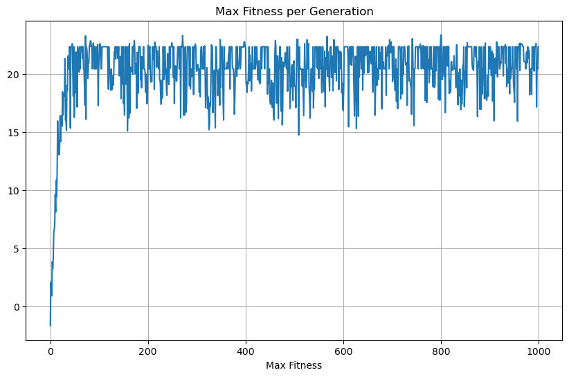

```python
import matplotlib.pyplot as plt
constants = Constants(1000, 100, 0.9, 0.1)
generation_z, num, kos_sher = find_optimal_solution(constants)
plt.figure(figsize = (10, 6))
generation_list = list(range(num))
plt.plot(kos_sher)
plt.title('Max Fitness per Generation')
plt.xlabel('Max Fitness')
plt.grid(True)
plt.show()
```

```python
value = (generation_z * data_frame['Value'].to_numpy()).sum(axis = 1).max()
weight = (generation_z * data_frame['Available Weight'].to_numpy()).sum(axis = 1).max()
value, weight
```

```
(21.428571424958868, 9.999999999827049)
```

```
 constants: max_generations: 1000 population_length: 200 p_crossover: 0.9 p_mutation: 0.1
On average took 1000.0 generations and took 6.25874137878418 seconds.
```

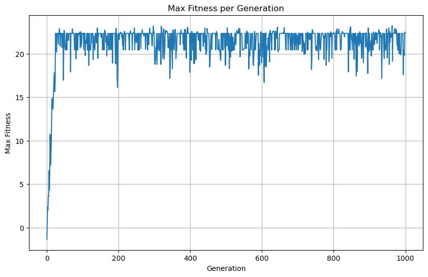

```python
constants = Constants(1000, 200, 0.9, 0.1)
num_of_total_generations, max_fitnesses = run_genetic(constants)
generation_z, num, kos_sher = find_optimal_solution(constants)
plt.figure(figsize = (10, 6))
generation_list = list(range(num))
plt.plot(kos_sher)
plt.title('Max Fitness per Generation')
plt.xlabel('Generation')
plt.ylabel('Max Fitness')
plt.grid(True)
plt.show()
```

```python
constants = Constants(1000, 100, 0.8, 0.05)
run_genetic(constants)
```

```
 constants: max_generations: 1000 population_length: 100 p_crossover: 0.8 p_mutation: 0.05
On average took 1000.0 generations and took 2.933670997619629 seconds.
```

[output not shown]

[output cut: 946 more lines]

```
  19.035695530439295,
  22.33333330796603,
  18.105217988924686,
  22.333333307966026,
  20.428571422012237,
  22.333333325305162,
  22.333333325305162,
  22.333333331,
  20.223381840351475,
  17.47282435105473,
  17.32483679187324,
  21.700285402782583,
  22.33333332633333,
  20.428571426145535,
  20.428571425462266])
```

```python
constants = Constants(1000, 100, 0.6, 0.05)
run_genetic(constants)
```

```
 constants: max_generations: 1000 population_length: 100 p_crossover: 0.6 p_mutation: 0.05
On average took 1000.0 generations and took 2.970747152964274 seconds.
```

[output not shown]

[output cut: 946 more lines]

```
  18.135616522544915,
  21.833415681994563,
  18.54865067657767,
  22.33333331735312,
  21.622427616984886,
  21.622427616984886,
  21.622427616984886,
  22.333333320690166,
  21.666468280773103,
  18.924866015788584,
  20.428571418816826,
  21.1559022825936,
  21.15590228660374,
  19.92414976266941,
  20.42857141343157])
```

# Questions

1. *What happens if the population is too big or too small?* If the population size is too small, we have less diversity in finding the optimal solution. If the population is too big, then we have a better chance in finding the optimal solution because we have more diversity but it takes more time and space.
2. *What happens if population increases after each generation?* Growth of population results in more diversity and better chance of finding more optimal solutions, however the issue of time and space remains. With population growth, it takes more and more time and space and it may not be very efficient. Also, growth of population in each generation, may distrupt the convergence.
3. *What are the effects of crossover and mutation and what happens if we use only one of them?* If we skip the Mutation phase, our solutions may only find a local optimum, and don't explore new and better optimal solutions. Mutation phase causes our chromosomes to explore around and they may find a better and more optimal solution. Crossover makes better chromosomes by combining good chromosomes but mutation is mostly used to make better chromosomes by directly changing the genes of one chromosome and helps us escape a local extremum. For example if we check the best fitness in the population of each generation, we can see that it converges to a number and then a mutation causes it to diverge from that number and suddenly increase. So we can't solve the problem by only using crossover.(uniform crossover may reach the answer but it will take too many generations) and in general only using mutation won't lead us to an optimal answer because it doesn't have the effect of crossover, however in this case for some constants, only using mutation leads to answer.
4. *What are some ways to find the answer faster?* We can play with parameters as I did in testing part to find the best values and find the answer as soon as possible.
5. *How can we solve the problem of chromosomes getting stuck after some generations?* As I said in question 3, mutation usually solves ths problem. we could also use multi-starting and run the algorithm with different initial populations to solve this issue.
6. *What can we do to stop the algorithm if the problem doesn't have any solutions?* We can set a limit for the number of generations. If the algorithm exceeds that limit and hasn't found a solution yet, we can stop the algorithm. Then we can return the chromosome with the best fitness in our population.